# Demand Forecasting of Lettuce

```r
library(forecast)
```

```r
library(tseries)
library(ggplot2)
```

#### **Reading the data**

```r
# numerical vector containing 103 daily observations of lettuce demand
restaurant_46673 <- read.csv("lettuce_series.csv")
head(restaurant_46673, 7)
```

|  | X | date | lettuceDemand |
| --- | --- | --- | --- |
| 1 | 0 | 15-03-05 | 152 |
| 2 | 1 | 15-03-06 | 100 |
| 3 | 2 | 15-03-07 | 54 |
| 4 | 3 | 15-03-08 | 199 |
| 5 | 4 | 15-03-09 | 166 |
| 6 | 5 | 15-03-10 | 143 |
| 7 | 6 | 15-03-11 | 162 |

#### **Create the time series object**

Since we only have 3 months of daily data on lettuce demand with a weekly cycle (and not an annual cycle) we shall use frequency = 7.

```r
#Convert the lettuceDemand column of the dataframe which is a numerical vector into a univariate time series object
restaurant_46673_ts <- ts(restaurant_46673[, 3], frequency = 7, start = c(03,05))
```

#### **Training and test data split**

```r
# training set (80%)
restaurant_46673_ts_train <- ts(restaurant_46673[1:83,3], frequency = 7)
# test set (20% - last 20 days)
restaurant_46673_ts_test <- restaurant_46673[84:nrow(restaurant_46673),3]
```

### **ARIMA (seasonal) Model**

##### **STEP 1 - IDENTIFICATION**

In the identification step we will find out if the time series is stationary in terms of trends, variance and seasonality both visually and through some tests.

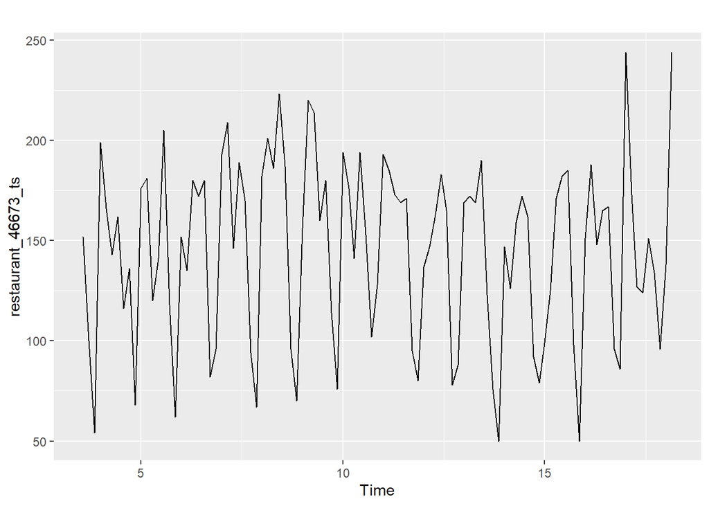

```r
# visual inspection of the time series
autoplot(restaurant_46673_ts)
```

```r
# testing if the time series is stationary - ADF test
adf.test(restaurant_46673_ts_train)
```

```
##
##  Augmented Dickey-Fuller Test
##
## data:  restaurant_46673_ts_train
## Dickey-Fuller = -7.4697, Lag order = 4, p-value = 0.01
## alternative hypothesis: stationary
```

```r
# testing if the time series is stationary - KPSS test
kpss.test(restaurant_46673_ts_train)
```

```
##
##  KPSS Test for Level Stationarity
##
## data:  restaurant_46673_ts_train
## KPSS Level = 0.1666, Truncation lag parameter = 3, p-value = 0.1
```

```r
# testing if the time series is stationary - PP test
pp.test(restaurant_46673_ts_train)
```

```
##
##  Phillips-Perron Unit Root Test
##
## data:  restaurant_46673_ts_train
## Dickey-Fuller Z(alpha) = -50.377, Truncation lag parameter = 3, p-value
## = 0.01
## alternative hypothesis: stationary
```

For the ADF and PP tests the null hypothesis states that the time series is NOT stationary. Both test reported p-values equal to 0.01.Upon comparing the p-value against 5% significance level that 0.05 (95% confidence level), the p-value is smaller than the significance level and the null hypothesis can be rejected. As a result, we can say that the time series is stationary.

Alternatively in the KPSS test whose null hypothesis is that, the time series is stationary, the p-value which is 0.1 is greater than 0.05, meaning that deviation from the null hypothesis is not statistically significant, and the null hypothesis is not rejected.

All the 3 tests are tailored for detecting non-stationarity in the form of a unit root in the process and their result suggests that the time series is stationary in other words, there are no trends which can also be observed visually from the output of the decompose() function and the variance is pretty same. However, they are not tailored for detecting non-stationarity of the seasonal kind.

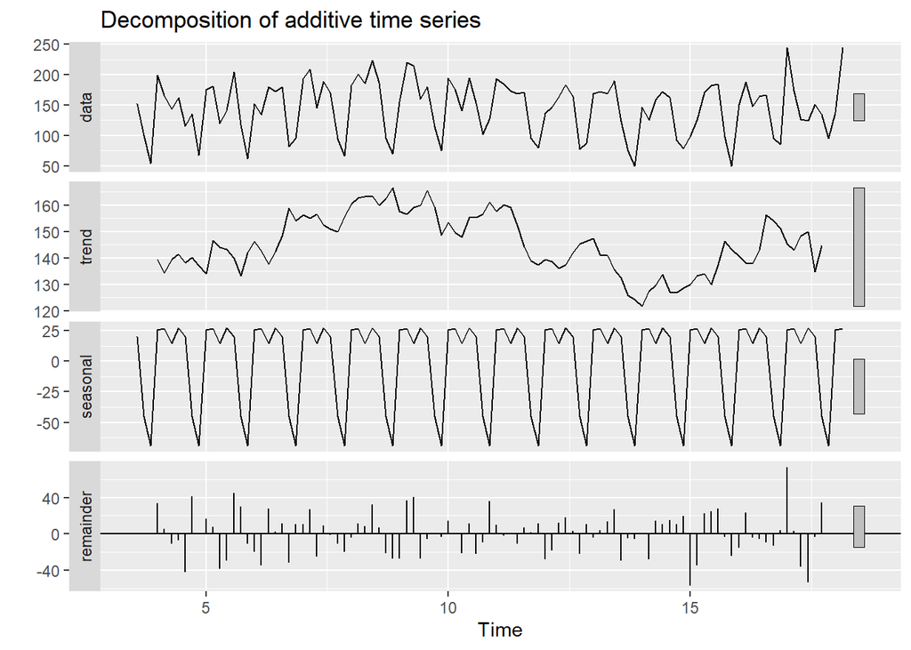

```r
# visualise the trend and seasonality of the time series by decomposing it
decompose = decompose(restaurant_46673_ts)
autoplot(decompose)
```

From the above plot we can observe that there is definitely seasonality in the given data, which is indicative of the relatively smaller grey bar in the seasonal panel. The seasonality has to be removed via differencing in order for us to use the ARIMA model effectively.Alternatively besides the visual examination, we can also detect seasonality through the function nsdiffs() like below.

The grey bar of the trend panel is very large, even larger than the grey bar of random remainder, which indicates that its contribution to the variation in the original time series is only marginal.

##### **Trend Part**

The ndiffs() result suggests that the we do not require any differencing the output being 0.

```r
#number of differencing needed to make time-series stationary (non seasonal part)
ndiffs(restaurant_46673_ts_train)
```

```
## [1] 0
```

##### **Seasonal Part**

The test result of nsdiffs() suggests that there are seasonal factors in the time-series and we will have to take first-order seasonal difference once (output being 1) to obtain a stationary time-series.

```r
#number of seasonal differencing needed to make time-series stationary
nsdiffs(restaurant_46673_ts_train)
```

```
## [1] 1
```

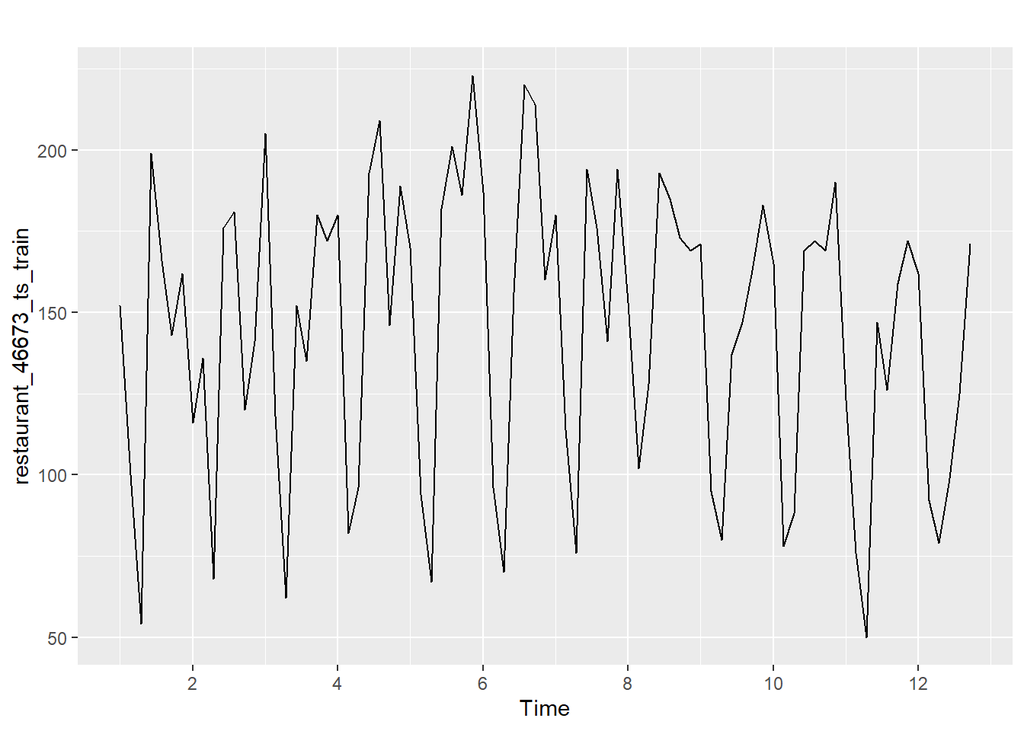

```r
#visualise the training data before removing seasonality
autoplot(restaurant_46673_ts_train)
```

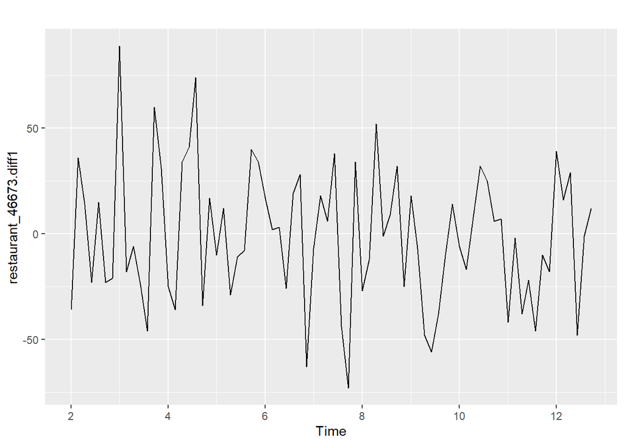

```r
#seasonal differencing of the time-series
restaurant_46673.diff1 <- diff(restaurant_46673_ts_train, lag = 7, differences = 1)
autoplot(restaurant_46673.diff1)
```

##### **Plotting ACF and PACF**

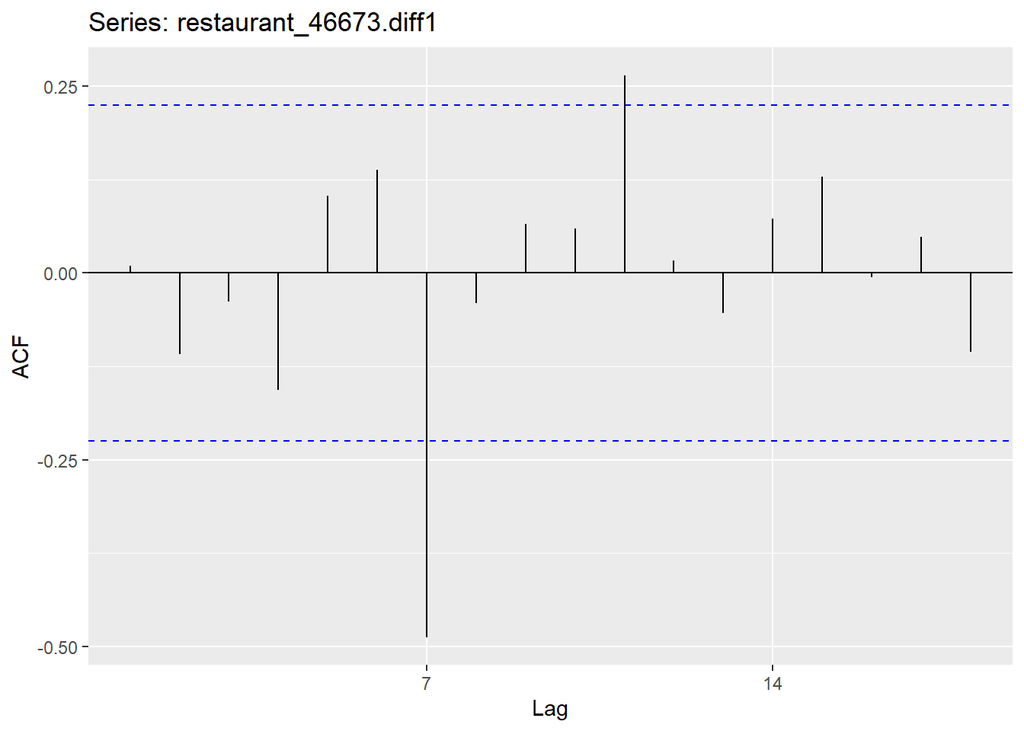

```r
#acf plot of seasonally differenced ts
ggAcf(restaurant_46673.diff1)
```

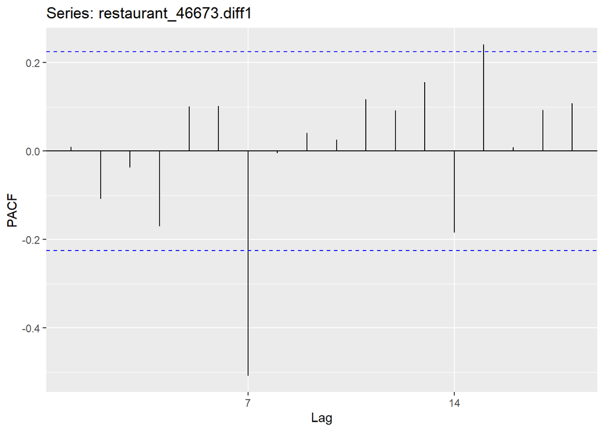

```r
#pacf plot of seasonally differenced ts
ggPacf(restaurant_46673.diff1)
```

##### **Inference of parameters for the ARIMA model from the ACF and PACF plots**

From the ACF and PACF plots of the stationarised time series we can infer that our order ‘P’ <= 2 as there are 2 spikes in the PACF plot and the order ‘Q’ <= 2 (2 spikes in the ACF plot) might be needed to find the best fitted SARIMA model. Additionally, we already know that a seasonal differencing ‘D’ of order 1 is needed.  
**NOTE:** Since the time series was trend stationary to begin with, the values for p, q and d can be set to 0.

##### **Checking if time series is stationary in terms of seasonality after seasonal differencing**

Upon checking the nsdiffs() of the seasonally differenced data, we see that the result is now 0 which confirms that data is stationary (in terms of seasonality) and we know that the data is level stationary free of trends from our earlier analysis using adf.test().

```r
#seasonal stationarity, how many seasonal differencing is needed ?
nsdiffs(restaurant_46673.diff1)
```

```
## [1] 0
```

By performing the nsdiffs() again, we can confirm that the time series is now stationary and is ready to apply the ARIMA model.

##### **Step 2 - ESTIMATION**

Since we already know that seasonal differencing is to be applied to the data to remove seasonality, we will specify D = 1 in the auto.arima() function to constraint our search space for the best model by evaluating only models that use first order seasonal differencing. The rest of the parameters like p, q, d, P and Q are all optimised within the autom.arima() function automatically.

```r
# application of the auto ARIMA model
autoarima = auto.arima(restaurant_46673_ts_train, D=1, trace = TRUE, ic = 'bic')
```

```
##
##  ARIMA(2,0,2)(1,1,1)[7] with drift         : 748.8765
##  ARIMA(0,0,0)(0,1,0)[7] with drift         : 751.6226
##  ARIMA(1,0,0)(1,1,0)[7] with drift         : 737.7853
##  ARIMA(0,0,1)(0,1,1)[7] with drift         : 732.1485
##  ARIMA(0,0,0)(0,1,0)[7]                    : 747.3656
##  ARIMA(0,0,1)(0,1,0)[7] with drift         : 755.9451
##  ARIMA(0,0,1)(1,1,1)[7] with drift         : 736.1791
##  ARIMA(0,0,1)(0,1,2)[7] with drift         : 736.1964
##  ARIMA(0,0,1)(1,1,0)[7] with drift         : 737.6987
##  ARIMA(0,0,1)(1,1,2)[7] with drift         : Inf
##  ARIMA(0,0,0)(0,1,1)[7] with drift         : 729.8582
##  ARIMA(0,0,0)(1,1,1)[7] with drift         : 734.111
##  ARIMA(0,0,0)(0,1,2)[7] with drift         : 734.1348
##  ARIMA(0,0,0)(1,1,0)[7] with drift         : 734.1678
##  ARIMA(0,0,0)(1,1,2)[7] with drift         : Inf
##  ARIMA(1,0,0)(0,1,1)[7] with drift         : 732.1984
##  ARIMA(1,0,1)(0,1,1)[7] with drift         : 736.4791
##  ARIMA(0,0,0)(0,1,1)[7]                    : 726.196
##  ARIMA(0,0,0)(1,1,1)[7]                    : 730.3108
##  ARIMA(0,0,0)(0,1,2)[7]                    : 730.3466
##  ARIMA(0,0,0)(1,1,0)[7]                    : 730.0613
##  ARIMA(0,0,0)(1,1,2)[7]                    : 734.4772
##  ARIMA(1,0,0)(0,1,1)[7]                    : 728.4228
##  ARIMA(0,0,1)(0,1,1)[7]                    : 728.3981
##  ARIMA(1,0,1)(0,1,1)[7]                    : 732.7235
##
##  Best model: ARIMA(0,0,0)(0,1,1)[7]
```

```r
summary(autoarima)
```

```
## Series: restaurant_46673_ts_train
## ARIMA(0,0,0)(0,1,1)[7]
##
## Coefficients:
##          sma1
##       -0.6463
## s.e.   0.1241
##
## sigma^2 = 711.1:  log likelihood = -358.77
## AIC=721.53   AICc=721.7   BIC=726.2
##
## Training set error measures:
##                      ME     RMSE      MAE       MPE    MAPE      MASE      ACF1
## Training set -0.9263843 25.34867 18.69599 -3.213122 13.8841 0.7111588 0.1621063
```

The above result suggests that the best model includes a seasonal MA(1) component, seasonal differencing of 1 with no AR component and with periodicity of 7 which is common when have daily data, as there is typically a weekly pattern in the time series.

Although the best model suggested by auto.arima() is ARIMA(0,0,0)(0,1,1)[7], we will try a couple of more custom ARIMA models based on our intuition from the ACF and PACF plots that we analysed in the identification step, so we have the chance to compare and choose the best model for forecasting.

```r
# custom estimation of ARIMA models
fitted_arima1 <- Arima(restaurant_46673_ts_train, order = c(0, 0, 0),seasonal = list(order = c(0, 1, 1), period = 7), include.drift = FALSE) # model1 -> given by auto.arima()

# Since value of P can be <= 2, we shall try the following 2 models
fitted_arima2 <- Arima(restaurant_46673_ts_train, order = c(1, 0, 0),seasonal = list(order = c(2, 1, 1), period = 7), include.drift = FALSE) # model2

fitted_arima3 <- Arima(restaurant_46673_ts_train, order = c(0, 0, 0),seasonal = list(order = c(2, 1, 1), period = 7), include.drift = FALSE) # model3
```

##### **Step 3 - VERIFICATION**

In this step, the residuals will tell us if the model was able to capture all of the information provided by the data.

To this end, We will analyse the graphs of the residuals, histograms and the ACF plots for all the 3 models that were tried in the previous steps.

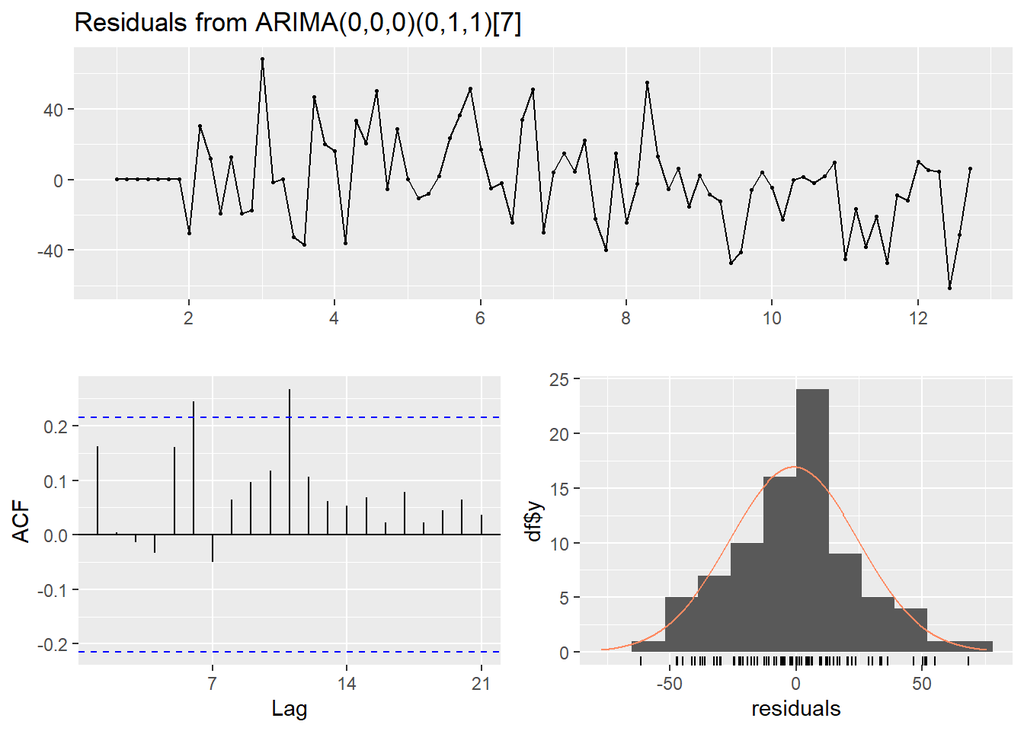

```
##
##  Ljung-Box test
##
## data:  Residuals from ARIMA(0,0,0)(0,1,1)[7]
## Q* = 21.814, df = 13, p-value = 0.05831
##
## Model df: 1.   Total lags used: 14
```

```r
#verification step
checkresiduals(fitted_arima1)
```

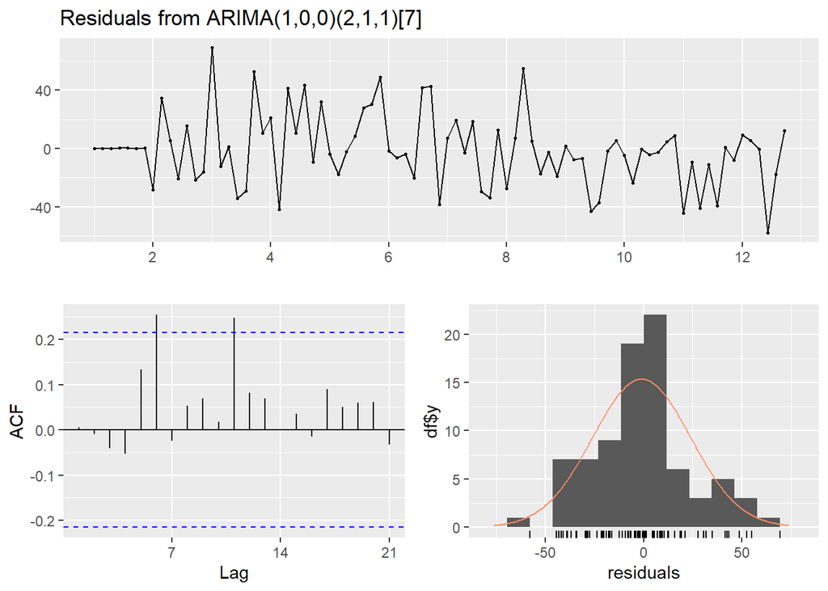

```
##
##  Ljung-Box test
##
## data:  Residuals from ARIMA(1,0,0)(2,1,1)[7]
## Q* = 15.925, df = 10, p-value = 0.1018
##
## Model df: 4.   Total lags used: 14
```

```r
checkresiduals(fitted_arima2)
```

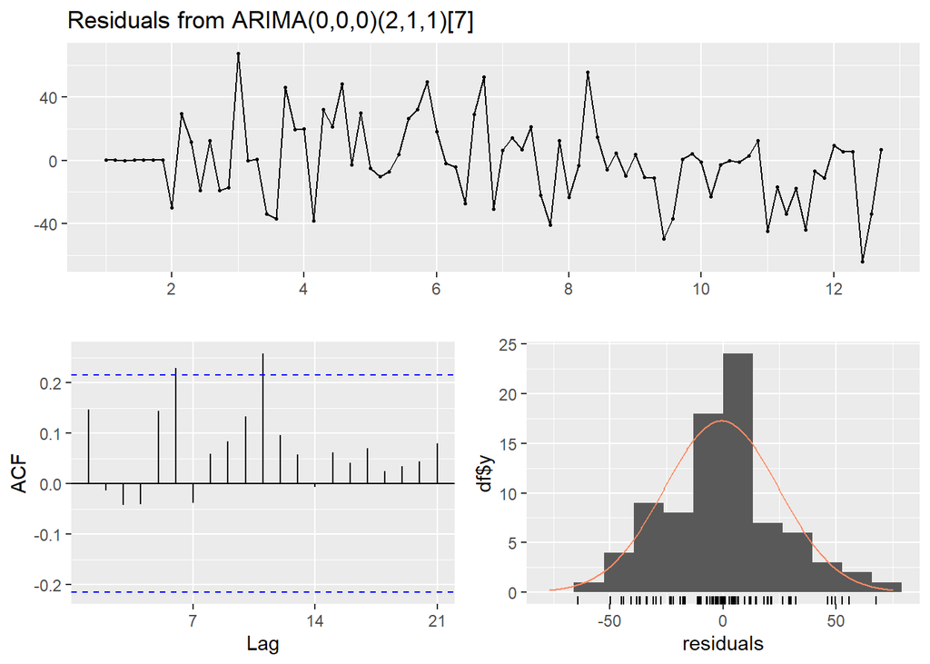

```
##
##  Ljung-Box test
##
## data:  Residuals from ARIMA(0,0,0)(2,1,1)[7]
## Q* = 19.516, df = 11, p-value = 0.05243
##
## Model df: 3.   Total lags used: 14
```

```r
checkresiduals(fitted_arima3)
```

Upon visual examination, we find that the residual graphs of all the 3 models seem to have a mean 0 and a constant variance more or less, which is indicative of white noise.

With regards to the **ACF plots** of the residuals of each of the 3 models, we can observe that almost all the spikes are within the 95% confidence band, in other words the lack of serial auto correlation among the lags of the residuals suggest that the forecasts are good.

The **histogram** of the residuals of fitted_arima2 model looks more “normally distributed” compared to the other 2 models namely fitted_arima1 and fitted_arima3 suggesting that the fitted_arima2 model produces forecasts that appears to have taken in to account all available information but this has to be confirmed by measuring the accuracy of the models.

Additionally, the **Ljung-Box test** that was also performed to show that the residuals have no remaining autocorrelations.

The Ljung-Box test uses the following hypotheses:

**H0:** The residuals are independently distributed.  
**H1:** The residuals are not independently distributed meaning they exhibit serial correlation

Since the p-values of the residuals of the 3 evaluated models are greater than 0.05 (5% significance level), we fail to reject the null hypothesis, confirming that the residuals are indeed random (white nosie).

### **Holt-Winters Model**

To apply the Holt-Winters method we shall use the ets() from the forecast package.The model parameters (errorterm, trend, seasonality) are represented by “ZZZ”. The error term usually being additive, we shall represent it by the letter A.

From the decomposition of the time series data, we know that there is no trend component hence the letter N is used to represent none.

Finally, for the seasonal component we shall use the letter A(additive) since the seasonal variations were constant over time. Hence the model we choose is “ANA” which can be compared against the model= “ZZZ” for any discripancies which automatically determines the type of each of the elements of the model namely errorterm, trend and seasonality.

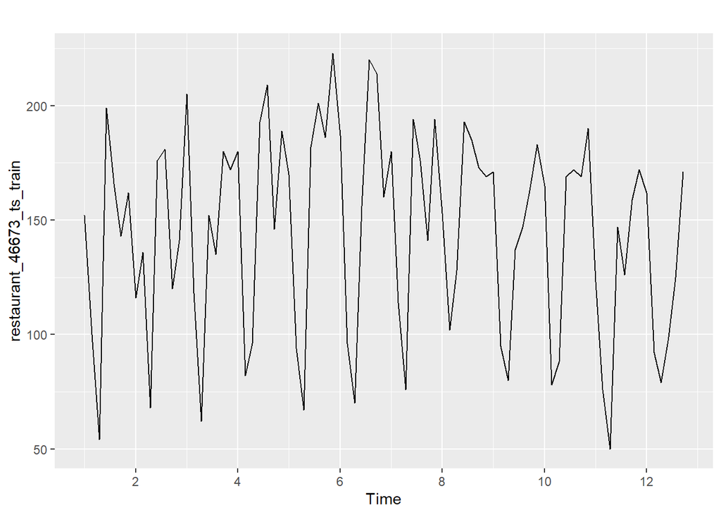

```r
autoplot(restaurant_46673_ts_train)
```

```r
ets1 <- ets(restaurant_46673_ts_train, model = "ANA")
ets2 <- ets(restaurant_46673_ts_train, model = "ZZZ")
```

```r
# optimal types of each element suggested by model = "ZZZ".
ets2
```

```
## ETS(A,N,A)
##
## Call:
##  ets(y = restaurant_46673_ts_train, model = "ZZZ")
##
##   Smoothing parameters:
##     alpha = 0.1135
##     gamma = 1e-04
##
##   Initial states:
##     l = 145.0957
##     s = 29.3732 19.2564 26.2776 23.638 -68.2592 -47.3313
##            17.0454
##
##   sigma:  24.6418
##
##      AIC     AICc      BIC
## 909.1752 912.2308 933.3636
```

In this case the best model proposed by using “ZZZ” is consistent with our choice of model.

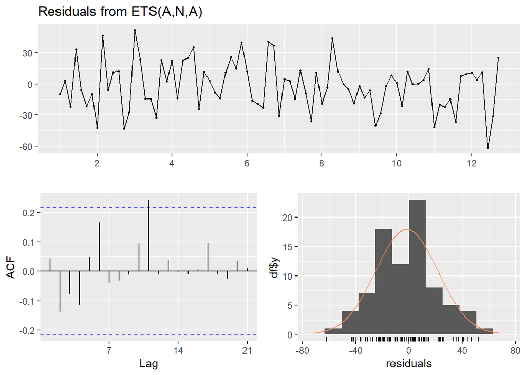

```
##
##  Ljung-Box test
##
## data:  Residuals from ETS(A,N,A)
## Q* = 13.325, df = 5, p-value = 0.02052
##
## Model df: 9.   Total lags used: 14
```

```r
#white noise verification of the residuals of ets1
checkresiduals(ets1)
```

Since the p-values of the residuals is 0.02 which is less than 0.05 (5% significance level), we reject the null hypothesis, confirming that the residuals are NOT independently distributed meaning they exhibit serial correlation and are not completely white noise.

### **Model comparison using the test set**

In this section, we shall compare the accuracy of each of the 4 models that we evaluated so far.  
**3 ARIMA models - fitted_arima1, fitted_arima2, fitted_arima3**  
**1 Holt-Winters ets model - ets1**

To choose the best model among the 4, we will use the root mean square measure as one of the criteria, the favorable model being the one with the least RMSE value after comparing the forecast of test data and the observed data (the last 20 days of data of the time series corresponds to the test data) using the accuracy() function.

```r
accuracy(forecast(fitted_arima1, h = 20), restaurant_46673_ts_test)
```

```
##                      ME     RMSE      MAE       MPE     MAPE      MASE
## Training set -0.9263843 25.34867 18.69599 -3.213122 13.88410 0.4396534
## Test set     13.0530481 40.73525 29.10376  4.199000 19.57526 0.6844016
##                   ACF1
## Training set 0.1621063
## Test set            NA
```

```r
accuracy(forecast(fitted_arima2, h = 20), restaurant_46673_ts_test)
```

```
##                     ME     RMSE      MAE       MPE     MAPE      MASE
## Training set -1.125248 24.85888 18.23078 -3.257723 13.53408 0.4287135
## Test set     16.848736 44.06803 32.11821  7.014114 21.45851 0.7552891
##                     ACF1
## Training set 0.005844604
## Test set              NA
```

```r
accuracy(forecast(fitted_arima3, h = 20), restaurant_46673_ts_test)
```

```
##                      ME     RMSE      MAE       MPE     MAPE      MASE     ACF1
## Training set -0.6772161 25.17493 18.55795 -3.002205 13.80022 0.4364073 0.146979
## Test set     12.4206232 39.79794 28.40297  4.012871 18.87026 0.6679219       NA
```

```r
accuracy(forecast(ets1, h = 20), restaurant_46673_ts_test)
```

```
##                     ME     RMSE      MAE       MPE     MAPE      MASE
## Training set -1.659807 23.26748 18.73355 -4.267896 14.55673 0.4405366
## Test set     18.857718 36.67258 27.42070 10.360048 18.39760 0.6448229
##                    ACF1
## Training set 0.04449914
## Test set             NA
```

From the test results we can observe that the “ets1” (Holt-Winters model) has the lowest RMSE value of 36.67 for its **test data**. On the other hand it’s residuals were not white noise hence we cannot consider the Holt-Winters model as the best model for forecasting.

We could in fact choose one of the 3 ARIMA models for forecasting, since all the 3 ARIMA models’s residuals were white noise owing to their p-values > than 0.05 from Ljung-Box test (there by failing to reject the null hypothesis).

### **Forecasting**

```r
# train the model on the entire dataset (training + test)
best_model <- Arima(restaurant_46673_ts, order = c(1, 0, 0),seasonal = list(order = c(2, 1, 1), period = 7), include.drift = FALSE)

# forecasting using the best fitted model for the next 2 weeks (14 days)
forecast_lettuce <- forecast(best_model, h = 14, level=c(95))

#demand of lettuce from 06/16/2015 to 06/29/2015 given by the PointForecast column
forecast_lettuce
```

```
##          Point Forecast     Lo 95    Hi 95
## 18.28571      169.38468 115.38608 223.3833
## 18.42857      172.63457 118.01656 227.2526
## 18.57143      164.11242 109.59699 218.6278
## 18.71429      102.14267  47.62692 156.6584
## 18.85714       77.48873  22.97297 132.0045
## 19.00000      168.12922 113.61346 222.6450
## 19.14286      179.29934 124.78358 233.8151
## 19.28571      160.60978 105.80009 215.4195
## 19.42857      172.63078 117.81721 227.4444
## 19.57143      164.25454 109.56659 218.9425
## 19.71429      101.17699  46.48903 155.8649
## 19.85714       76.84535  22.15740 131.5333
## 20.00000      168.44051 113.75255 223.1285
## 20.14286      177.36142 122.67347 232.0494
```